# Design Matrix implementation for Hierarchical EZ-DDM in JAGS

# Overview

This document presents a JAGS replication of the simulation study conducted in STAN by Anne Giacobello (see `/working simulation + output/`). The key feature of this implementation is the **design matrix approach**, which allows flexible specification of predictors for each DDM parameter without rewriting the model.

## Design matrix specification

The model uses three **3D design arrays** to specify predictors for each DDM parameter. Each array has dimensions $I \times K \times P$, where for each participant $i$ and condition $k$, the slice $X[i,k,]$ is a row vector of $P$ predictor values.

| Parameter | Design Array | Dimensions | Predictors |
| --- | --- | --- | --- |
| $\nu$ (drift) | $X_\nu[i,k,p]$ | $I \times K \times P_\nu$ | Intercept + Condition (Dummy) |
| $\alpha$ (boundary) | $X_\alpha[i,k,p]$ | $I \times K \times P_\alpha$ | Intercept + Covariate (Continuous) |
| $\tau$ (non-decision) | $X_\tau[i,k,p]$ | $I \times K \times P_\tau$ | Intercept only |

Where:

- $I$ = number of participants
- $K$ = number of conditions (within-subject cells).
- $J$ = number of trials per participant per condition (used to form the cell-level summary statistics)
- $P$ = number of predictors (including intercept) for each parameter:
  - $P_\nu = 2$: intercept + dummy-coded condition (0 for condition 1, 1 for condition 2)
  - $P_\alpha = 2$: intercept + continuous between-subject covariate $x_i$
  - $P_\tau = 1$: intercept only (no condition or covariate effects)

The $I \times K \times P$ structure enables generality. Using the same 3D structure for all parameters allows uniform indexing in the JAGS model code and supports future extensions (e.g., participant-by-condition interactions).

The model computes linear predictors using inner products: $\mu_{\nu,ik} = X_\nu[i,k,] \cdot \beta_\nu$. This works regardless of how many predictors you have, because the inner product handles vectors of any length. This means that we could change $P$ (number of predictors) and/or the values in $X$ (which predictors to include) without rewriting the model code.

For example, to add a second covariate to $\alpha$, just set $P_\alpha = 3$ and $X_\alpha[i,k,] = [1, x_{1,i}, x_{2,i}]$. No model rewriting needed.

## Hierarchical structure

**Population-level parameters:**

- $\beta_{\nu,1}$ = population mean drift rate (intercept, when condition = 0)
- $\beta_{\nu,2}$ = population mean condition effect on drift
- $\beta_{\alpha,1}$ = population mean boundary separation (intercept)
- $\beta_{\alpha,2}$ = covariate effect on boundary
- $\beta_{\tau,1}$ = population mean non-decision time

**Individual-level random effects:**

- $v_i \sim \text{Normal}(0, \sigma_v)$ = participant-specific deviation from the mean condition effect
- $x_i \sim \text{Normal}(0, 1)$ = standardized covariate value for participant $i$

**Linear predictors for expected values:**

$$\mu_{\nu,ik} = \beta_{\nu,1} + (\beta_{\nu,2} + v_i) \cdot \text{cond}_k$$

$$\mu_{\alpha,ik} = \beta_{\alpha,1} + \beta_{\alpha,2} \cdot x_i$$

$$\mu_{\tau,ik} = \beta_{\tau,1}$$

Where $\text{cond}_k$ is a dummy variable (0 for condition 1, 1 for condition 2).

**Individual parameters (with residual variability):**

$$\nu_{ik} \sim \text{Normal}(\mu_{\nu,ik}, \sigma_\nu)$$

$$\alpha_{ik} \sim \text{Normal}(\mu_{\alpha,ik}, \sigma_\alpha) \text{ truncated to } [0.1, 3.0]$$

$$\tau_{ik} \sim \text{Normal}(\mu_{\tau,ik}, \sigma_\tau) \text{ truncated to } [0.05, \infty)$$

## Simulation Design

Following Anne’s STAN implementation:

```r
I_vals <- c(80, 160)   # Number of participants
J_vals <- c(80, 160)   # Trials per condition
K      <- 2            # Number of conditions
N_sim  <- 3            # Replications per cell

# Store design in a grid
sim_grid <- expand.grid(I = I_vals,
                        J = J_vals,
                        sim = 1:N_sim)
print(sim_grid)
```

```
##      I   J sim
## 1   80  80   1
## 2  160  80   1
## 3   80 160   1
## 4  160 160   1
## 5   80  80   2
## 6  160  80   2
## 7   80 160   2
## 8  160 160   2
## 9   80  80   3
## 10 160  80   3
## 11  80 160   3
## 12 160 160   3
```

**Total simulations:** $2 \times 2 \times 3 = 12$

# True Parameter Values

```r
#===============================================================================
# True population parameters (matching Anne's STAN simulation)
#===============================================================================
true_pars <- list(
    # Drift rate (nu) parameters
    mu_nu    = 0.50,   # Population intercept
    b1_nu    = 0.20,   # Fixed condition effect
    sigma_nu = 0.18,   # Residual SD
    sigma_v  = 0.20,   # Random slope SD

    # Boundary separation (alpha) parameters
    mu_alpha  = 1.50,  # Population intercept
    b_alpha   = 0.30,  # Covariate effect
    sigma_alpha = 0.25,# Residual SD

    # Non-decision time (tau) parameters
    mu_tau    = 0.30,  # Population intercept
    sigma_tau = 0.15   # Residual SD
)
```

# JAGS Model with Design Matrices

```r
#===============================================================================
# Write JAGS model file
#===============================================================================
modelFile <- here("JAGS", "demos", "simulation-study", "design_matrix",
                  "model_design_matrix.bug")

model_code <- "
model {
    #===================================================================
    # PRIORS: Population-level regression coefficients
    #===================================================================

    # Drift rate coefficients: beta_nu[1] = intercept, beta_nu[2] = condition effect
    for (p in 1:P_nu) {
        beta_nu[p] ~ dnorm(prior_beta_nu[1, p], pow(prior_beta_nu[2, p], -2))
    }

    # Boundary coefficients: beta_alpha[1] = intercept, beta_alpha[2] = covariate effect
    for (p in 1:P_alpha) {
        beta_alpha[p] ~ dnorm(prior_beta_alpha[1, p], pow(prior_beta_alpha[2, p], -2))
    }

    # Non-decision time coefficients: beta_tau[1] = intercept only
    for (p in 1:P_tau) {
        beta_tau[p] ~ dnorm(prior_beta_tau[1, p], pow(prior_beta_tau[2, p], -2))
    }

    #===================================================================
    # PRIORS: Variance components
    #===================================================================
    sigma_nu    ~ dnorm(prior_sigma_nu[1], pow(prior_sigma_nu[2], -2)) T(0, )
    sigma_alpha ~ dnorm(prior_sigma_alpha[1], pow(prior_sigma_alpha[2], -2)) T(0.1, 0.8)
    sigma_tau   ~ dnorm(prior_sigma_tau[1], pow(prior_sigma_tau[2], -2)) T(0.05, 0.6)
    sigma_v     ~ dnorm(prior_sigma_v[1], pow(prior_sigma_v[2], -2)) T(0, )

    #===================================================================
    # RANDOM SLOPES (Non-centered parameterization)
    #===================================================================
    for (i in 1:I) {
        z_v[i] ~ dnorm(0, 1)
        v[i] <- beta_nu[2] + sigma_v * z_v[i]  # Participant's condition effect
    }

    #===================================================================
    # INDIVIDUAL PARAMETERS AND LIKELIHOOD
    #===================================================================
    for (i in 1:I) {
        for (k in 1:K) {

            #---------------------------------------------------------------
            # Linear predictors using design matrices
            #---------------------------------------------------------------
            # mu_nu: intercept + participant's random slope * condition dummy
            mu_nu[i,k] <- beta_nu[1] + v[i] * X_nu[i, k, 2]

            # mu_alpha: design matrix multiplication
            mu_alpha[i,k] <- inprod(X_alpha[i, k, 1:P_alpha], beta_alpha[1:P_alpha])

            # mu_tau: design matrix multiplication (intercept only here)
            mu_tau[i,k] <- inprod(X_tau[i, k, 1:P_tau], beta_tau[1:P_tau])

            #---------------------------------------------------------------
            # Individual DDM parameters
            #---------------------------------------------------------------
            drift[i,k] ~ dnorm(mu_nu[i,k], pow(sigma_nu, -2))
            bound[i,k] ~ dnorm(mu_alpha[i,k], pow(sigma_alpha, -2)) T(0.1, 3.0)
            nondt[i,k] ~ dnorm(mu_tau[i,k], pow(sigma_tau, -2)) T(0.05, )

            #---------------------------------------------------------------
            # EZ-DDM Forward Equations
            #---------------------------------------------------------------
            ey[i,k] <- exp(-bound[i,k] * drift[i,k])
            Pc[i,k] <- 1 / (1 + ey[i,k])
            MDT[i,k] <- (bound[i,k] / (2 * drift[i,k])) * (1 - ey[i,k]) / (1 + ey[i,k])
            MRT[i,k] <- MDT[i,k] + nondt[i,k]
            PRT[i,k] <- 2 * pow(drift[i,k], 3) / bound[i,k] *
                        pow(ey[i,k] + 1, 2) /
                        (2 * -bound[i,k] * drift[i,k] * ey[i,k] - pow(ey[i,k], 2) + 1)

            #---------------------------------------------------------------
            # Likelihood: Sampling distributions for summary statistics
            #---------------------------------------------------------------
            C[i,k] ~ dbin(Pc[i,k], J[i,k])
            meanRT[i,k] ~ dnorm(MRT[i,k], PRT[i,k] * J[i,k])
            varRT[i,k] ~ dnorm(1/PRT[i,k], 0.5 * (J[i,k] - 1) * pow(PRT[i,k], 2))
        }
    }
}
"

# Write model to file
dir.create(dirname(modelFile), showWarnings = FALSE, recursive = TRUE)
writeLines(model_code, modelFile)
```

## Design matrix automatization

The model code above is written so that `P` and `X` values can be changed **without rewriting the model**. This is because…

1. The model loops over `P` to specify priors for each coefficient

```r
for (p in 1:P_nu) {
    beta_nu[p] ~ dnorm(prior_beta_nu[1, p], pow(prior_beta_nu[2, p], -2))
}
```

In this case, the loop creates as many beta coefficients as specified by `P_nu`. If `P_nu = 2`, you get `beta_nu[1]` and `beta_nu[2]`. If `P_nu = 5`, you immediately get 5 coefficients with no code modification.

2. The model uses `inprod()` to compute linear predictors

```r
mu_alpha[i,k] <- inprod(X_alpha[i, k, 1:P_alpha], beta_alpha[1:P_alpha])
mu_tau[i,k]   <- inprod(X_tau[i, k, 1:P_tau], beta_tau[1:P_tau])
```

The `inprod()` function computes the inner product (dot product) of two vectors. The indexing `1:P_alpha` adapts to whatever value `P_alpha` has, so **this works for any number of predictors.**

3. The model passes `P_nu`, `P_alpha`, `P_tau` and the design arrays `X_nu`, `X_alpha`, `X_tau` to JAGS as data, not hardcoded. For example, to add a second covariate to $\alpha$, you can set `P_alpha = 3` and `X_alpha[i,k,] = [1, x1, x2]`.

# Run Simulations

### Source Custom Functions

```r
#===============================================================================
# Source custom functions from /src/
#===============================================================================
source(here("JAGS", "src", "generate_truePars.R"))
source(here("JAGS", "src", "generate_trialData.R"))
source(here("JAGS", "src", "calculate_sumStats.R"))
source(here("JAGS", "src", "calculate_Rhat.R"))
source(here("JAGS", "src", "plot_recovery.R"))
source(here("JAGS", "src", "simulation_settings.R"))
```

### Write custom function to run each simulation cell

We define a custom function to run each simulation in the simulation study.

1. Generates individual true parameters, as appropriate for the design
2. Generates trial-level data and computes summary statistics
3. Builds the corresponding 3D design arrays
4. Prepares priors and data for JAGS
5. Runs the JAGS model
6. Extracts and returns results

This function is supported by the custom functions loaded above (stored in `/JAGS/src/`).

```r
run_one_simulation <- function(I, J, K, true_pars, modelFile,
                                P_nu = 2, P_alpha = 2, P_tau = 1,
                                n.chains = 4, n.iter = 5000,
                                n.burnin = 1000, n.thin = 1) {

    # Condition dummy coding (0 for condition 1, 1 for condition 2, etc.)
    cond_dummy <- 0:(K - 1)

    #--------------------------------------------------------------------
    # Step 1: Generate true parameters
    #--------------------------------------------------------------------
    true_result <- generate_truePars_condition(
        n_sub      = I,
        n_cond     = K,
        drift_mean = true_pars$mu_nu,
        drift_cond = true_pars$b1_nu,
        drift_sd   = true_pars$sigma_nu,
        slope_sd   = true_pars$sigma_v,
        bound_mean = true_pars$mu_alpha,
        bound_cov  = if (!is.null(true_pars$b_alpha)) true_pars$b_alpha else 0,
        bound_sd   = true_pars$sigma_alpha,
        nondt_mean = true_pars$mu_tau,
        nondt_cond = if (!is.null(true_pars$b1_tau)) true_pars$b1_tau else 0,
        nondt_sd   = true_pars$sigma_tau)

    # Extract components
    # Data frame: subject, condition, drift, bound, non-decision time
    pars_df <- true_result$pars
    # Data frame: subject, v (random slope), x (covariate)
    rand_eff <- true_result$random_effects

    #---------------------------------------------------------------------------
    # Step 2: Generate trial-level data and compute summary statistics
    #---------------------------------------------------------------------------
    C_mat   <- matrix(NA, I, K) # Accuracy data
    MRT_mat <- matrix(NA, I, K) # Mean RT data
    VRT_mat <- matrix(NA, I, K) # Variance RT data

    for (i in 1:I) {
        for (k in 1:K) {
            # Get parameters for this subject x condition
            row_idx <- which(pars_df$sub == i & pars_df$cond == (k - 1))

            # Generate trial-level data using /src/ function
            trial_data <- sample_many_trials(
                a = pars_df$bound[row_idx],
                v = pars_df$drift[row_idx],
                t = pars_df$nondt[row_idx],
                n = J)

            # Compute summary statistics from trial data
            C_mat[i, k]   <- sum(trial_data$accuracy)
            MRT_mat[i, k] <- mean(trial_data$RT)
            VRT_mat[i, k] <- var(trial_data$RT)
        }
    }

    #---------------------------------------------------------------------------
    # Step 3: Build design arrays
    #---------------------------------------------------------------------------
    # Initialize design arrays
    X_nu    <- array(NA, dim = c(I, K, P_nu))
    X_alpha <- array(NA, dim = c(I, K, P_alpha))
    X_tau   <- array(NA, dim = c(I, K, P_tau))

    # Fill design arrays
    for (i in 1:I) {
        for (k in 1:K) {
            # X_nu: Intercept (+ condition dummy if P_nu > 1)
            X_nu[i, k, ] <- if (P_nu == 1) 1 else c(1, cond_dummy[k])

            # X_alpha: Intercept (+ covariate if P_alpha > 1)
            X_alpha[i, k, ] <- if (P_alpha == 1) 1 else c(1, rand_eff$x[i])

            # X_tau: Intercept (+ condition dummy if P_tau > 1)
            X_tau[i, k, ] <- if (P_tau == 1) 1 else c(1, cond_dummy[k])
        }
    }

    #---------------------------------------------------------------------------
    # Step 4: Set priors
    #---------------------------------------------------------------------------
    prior_beta_nu <- if (P_nu == 1) {
        matrix(c(0.5, 0.5), nrow = 2)
    } else {
        matrix(c(0.5, 0.2, 0.5, 0.5), nrow = 2, byrow = TRUE)
    }

    prior_beta_alpha <- if (P_alpha == 1) {
        matrix(c(1.5, 0.5), nrow = 2)
    } else {
        matrix(c(1.5, 0.0, 0.5, 0.5), nrow = 2, byrow = TRUE)
    }

    prior_beta_tau <- if (P_tau == 1) {
        matrix(c(0.3, 0.2), nrow = 2)
    } else {
        matrix(c(0.3, 0.05, 0.2, 0.2), nrow = 2, byrow = TRUE)
    }

    prior_sigma_nu    <- c(0.3, 0.3)
    prior_sigma_alpha <- c(0.3, 0.3)
    prior_sigma_tau   <- c(0.15, 0.15)
    prior_sigma_v     <- c(0.2, 0.2)

    #---------------------------------------------------------------------------
    # Step 5: Prepare data for JAGS
    #---------------------------------------------------------------------------
    J_mat <- matrix(J, I, K)

    data_toJAGS <- list(I = I, K = K,
                        P_nu = P_nu, P_alpha = P_alpha, P_tau = P_tau,
                        J = J_mat, C = C_mat,
                        meanRT = MRT_mat, varRT = VRT_mat,
                        X_nu = X_nu, X_alpha = X_alpha, X_tau = X_tau,
                        prior_beta_nu = prior_beta_nu,
                        prior_beta_alpha = prior_beta_alpha,
                        prior_beta_tau = prior_beta_tau,
                        prior_sigma_nu = prior_sigma_nu,
                        prior_sigma_alpha = prior_sigma_alpha,
                        prior_sigma_tau = prior_sigma_tau,
                        prior_sigma_v = prior_sigma_v)

    #---------------------------------------------------------------------------
    # Step 6: Run JAGS
    #---------------------------------------------------------------------------
    parameters <- c('beta_nu', 'beta_alpha', 'beta_tau',
                    'sigma_nu', 'sigma_alpha', 'sigma_tau', 'sigma_v',
                    'drift', 'bound', 'nondt', 'v')

    myinits <- replicate(n.chains, list(
                beta_nu    = if (P_nu == 1) 0.5 else c(0.5, 0.2),
                beta_alpha = if (P_alpha == 1) 1.5 else c(1.5, 0),
                beta_tau   = if (P_tau == 1) 0.3 else c(0.3, 0.05),
                sigma_nu = 0.2,
                sigma_alpha = 0.3,
                sigma_tau = 0.15,
                sigma_v = 0.2), simplify = FALSE)

    samples <- jags(data = data_toJAGS,
                    parameters.to.save = parameters,
                    model.file = modelFile,
                    n.chains = n.chains, n.iter = n.iter,
                    n.burnin = n.burnin, n.thin = n.thin,
                    DIC = FALSE, inits = myinits)

    #---------------------------------------------------------------------------
    # Step 7: Extract results
    #---------------------------------------------------------------------------
    sims <- samples$BUGSoutput$sims.matrix

    #---------------------------------------------------------------------------
    # 7a. Population-level estimates (using helper functions from /src/)
    #---------------------------------------------------------------------------
    pop_est <- build_pop_estimates(sims, P_nu, P_alpha, P_tau)
    pop_true <- build_pop_true(true_pars, P_nu, P_alpha, P_tau)

    #---------------------------------------------------------------------------
    # 7b. Individual-level estimates (drift, bound, nondt by subject x condition)
    #---------------------------------------------------------------------------
    # Initialize storage for individual estimates
    drift_est <- matrix(NA, I, K)
    bound_est <- matrix(NA, I, K)
    nondt_est <- matrix(NA, I, K)

    for (i in 1:I) {
        for (k in 1:K) {
            drift_est[i, k] <- mean(sims[, paste0("drift[", i, ",", k, "]")])
            bound_est[i, k] <- mean(sims[, paste0("bound[", i, ",", k, "]")])
            nondt_est[i, k] <- mean(sims[, paste0("nondt[", i, ",", k, "]")])
        }
    }

    # Random slope estimates (v[i])
    v_est <- numeric(I)
    for (i in 1:I) {
        v_est[i] <- mean(sims[, paste0("v[", i, "]")])
    }
     # Intercept + condition effect
    # True individual values (from pars_df)
    drift_true <- matrix(pars_df$drift, nrow = I, ncol = K, byrow = TRUE)
    bound_true <- matrix(pars_df$bound, nrow = I, ncol = K, byrow = TRUE)
    nondt_true <- matrix(pars_df$nondt, nrow = I, ncol = K, byrow = TRUE)
    v_true <- rand_eff$v

    # Build individual-level results data frame
    results_indiv <- data.frame(
            sub = rep(1:I, times = K),
            condition = rep(0:(K-1), each = I),
            true_drift = as.vector(drift_true),
            est_drift  = as.vector(drift_est),
            true_bound = as.vector(bound_true),
            est_bound  = as.vector(bound_est),
            true_nondt = as.vector(nondt_true),
            est_nondt  = as.vector(nondt_est))

    # Random slope results (one per subject)
    results_v <- data.frame(sub = 1:I, true_v = v_true,
                            est_v = v_est)

    #---------------------------------------------------------------------------
    # 7c. Convergence diagnostics (using helper function from /src/)
    #---------------------------------------------------------------------------
    pop_par_names <- get_rhat_params(P_nu, P_alpha, P_tau)
    rhat_vals <- sapply(pop_par_names, function(p) getRhat(samples$BUGSoutput$sims.array[, , p]))

    return(list(pop_est = pop_est,
                pop_true = pop_true,
                results_indiv = results_indiv,
                results_v = results_v,
                rhat_max = max(rhat_vals),
                converged = max(rhat_vals) < 1.05,
                I = I, J = J))
}
```

**Notes:**

- `P_nu`, `P_alpha`, `P_tau` are optional arguments (defaults: 2, 2, 1 matching STAN’s design on file `working simulation + output/sim_and_rec_model2_ncp`)
- Helper functions in `/src/simulation_settings.R` handle parameter extraction for any P values
- The same JAGS model file works for any design. We only need to change the data passed to the function.

## Run full simulation study

We check if cached results exist, and if not, run the full simulation study.

```r
# Results file:
resultsFile <- here("JAGS", "demos", "simulation-study", "design_matrix",
                    "simulation_results.RData")

# IF the results file exists, load the results
if(file.exists(resultsFile)) {
    load(resultsFile)
# If the results file does not exist, run the simulations
} else {
    results_list <- vector("list", nrow(sim_grid))

    for (r in 1:nrow(sim_grid)) {
        set.seed(r)

        cat("Running simulation", r, "of", nrow(sim_grid),
            "| I =", sim_grid$I[r], "| J =", sim_grid$J[r], "\n")

        results_list[[r]] <- run_one_simulation(
            I = sim_grid$I[r], J = sim_grid$J[r],
            K = K, true_pars = true_pars, modelFile = modelFile)
    }

    # Create the results file
    save(results_list, sim_grid, true_pars, file = resultsFile)
}
```

## Parameter Recovery Results

### Aggregate results across all cells

```r
#-------------------------------------------------------------------------------
# Population-level results
#-------------------------------------------------------------------------------
pop_results <- do.call(rbind, lapply(seq_along(results_list), function(r) {
    res <- results_list[[r]]
    data.frame(sim = r, I = res$I, J = res$J,
               param = names(res$pop_est),
               true_value = res$pop_true,
               estimate = res$pop_est,
               converged = res$converged)
}))

#-------------------------------------------------------------------------------
# Individual-level results
#-------------------------------------------------------------------------------
results_indiv_all <- do.call(rbind, lapply(seq_along(results_list), function(r) {
    res <- results_list[[r]]
    if (!res$converged) return(NULL)  # Skip non-converged runs

    df <- res$results_indiv
    df$sim <- r
    df$I <- res$I
    df$J <- res$J
    df
}))

#-------------------------------------------------------------------------------
# Random slope results (v[i])
#-------------------------------------------------------------------------------
results_v_all <- do.call(rbind, lapply(seq_along(results_list), function(r) {
    res <- results_list[[r]]
    if (!res$converged) return(NULL)

    df <- res$results_v
    df$sim <- r
    df$I <- res$I
    df$J <- res$J
    # Add population mean to get total condition effect (as done by Anne)
    df$true_v_total <- df$true_v + true_pars$b1_nu
    df$est_v_total <- df$est_v  # Model estimates total effect directly
    df
}))

#-------------------------------------------------------------------------------
# Convergence summary
#-------------------------------------------------------------------------------
cat("Failed:", sum(!sapply(results_list, function(x) x$converged)), "\n")
```

```
## Failed: 0
```

### Individual-level parameter recovery

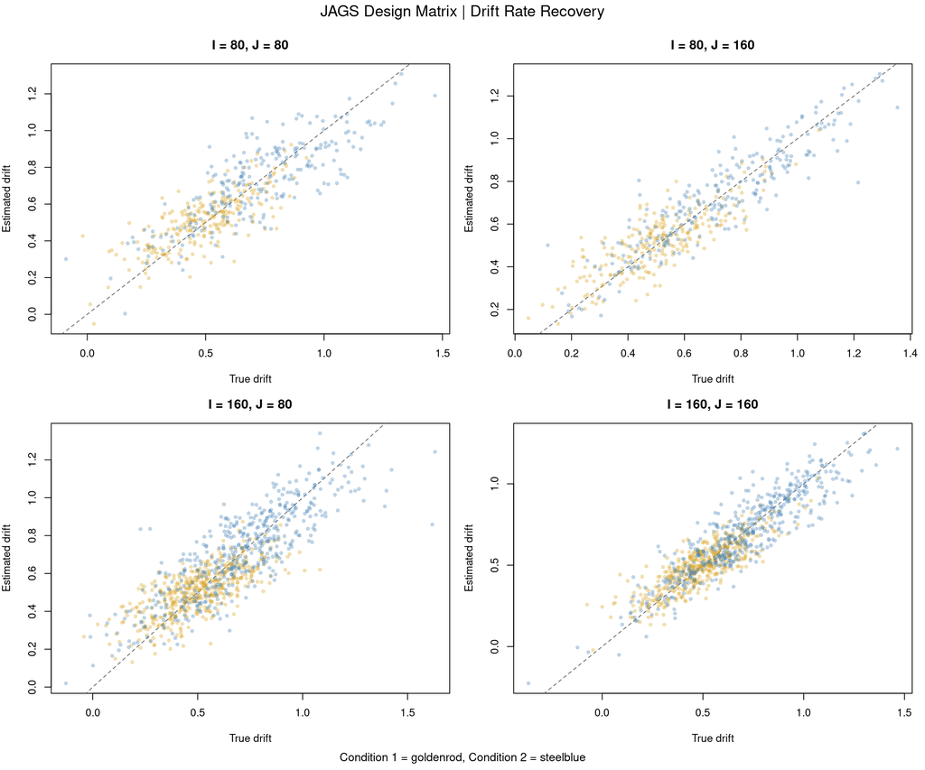

```r
# Drift rate recovery
plot_recovery_faceted(results_indiv_all, "true_drift", "est_drift",
                       "JAGS Design Matrix | Drift Rate Recovery",
                       "True drift", "Estimated drift",
                       I_vals, J_vals, by_condition = TRUE)
```

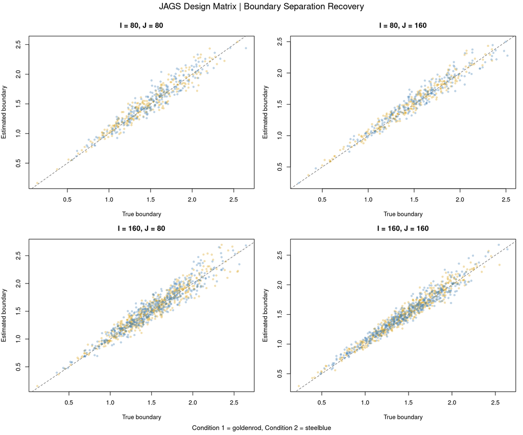

```r
# Boundary separation recovery
plot_recovery_faceted(results_indiv_all, "true_bound", "est_bound",
                       "JAGS Design Matrix | Boundary Separation Recovery",
                       "True boundary", "Estimated boundary",
                       I_vals, J_vals, by_condition = TRUE)
```

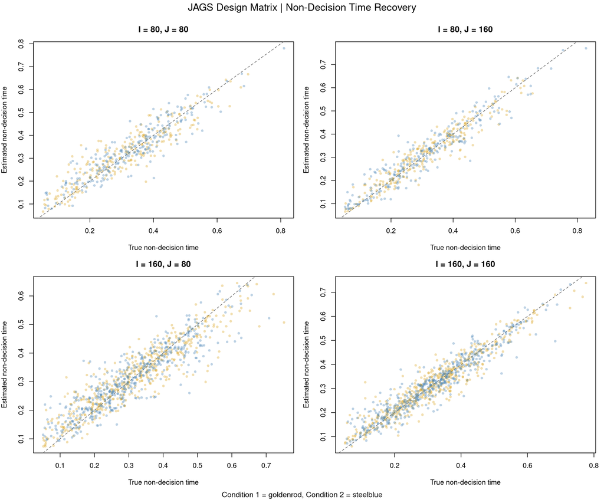

```r
# Non-decision time recovery
plot_recovery_faceted(results_indiv_all, "true_nondt", "est_nondt",
                       "JAGS Design Matrix | Non-Decision Time Recovery",
                       "True non-decision time", "Estimated non-decision time",
                       I_vals, J_vals, by_condition = TRUE)
```

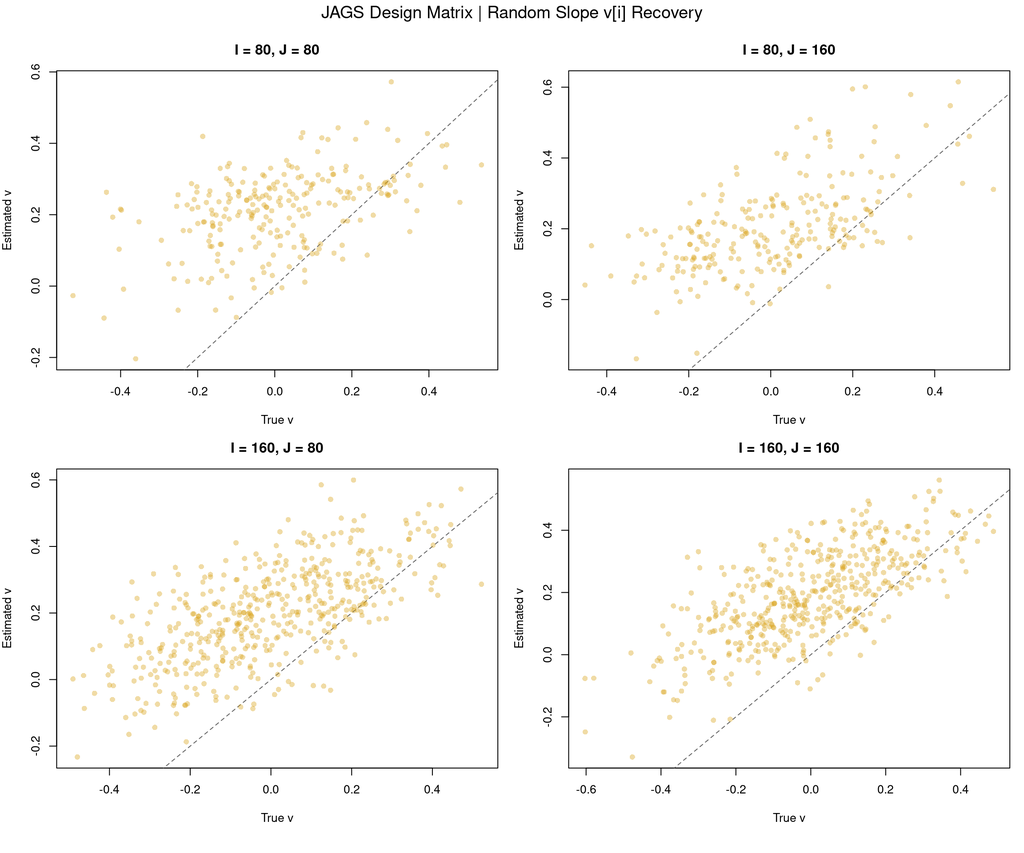

```r
# Random slope recovery
plot_recovery_faceted(results_v_all, "true_v", "est_v",
                       "JAGS Design Matrix | Random Slope v[i] Recovery",
                       "True v", "Estimated v",
                       I_vals, J_vals, by_condition = FALSE)
```

There is a hidden r chunk in this .Rmd file that saves all the individual-level plots to `JAGS/demos/simulation-study/design_matrix/figures` (the directory is created if it doesn’t exist).

```
## Plots saved to: /home/babymagikarp/Desktop/BayEZ/JAGS/demos/simulation-study/design_matrix/figures
```

## Population-Level Recovery

As a precaution, we make sure to only plot the population-level results for simulations that converged.

```r
pop_converged <- pop_results[pop_results$converged, ]
```

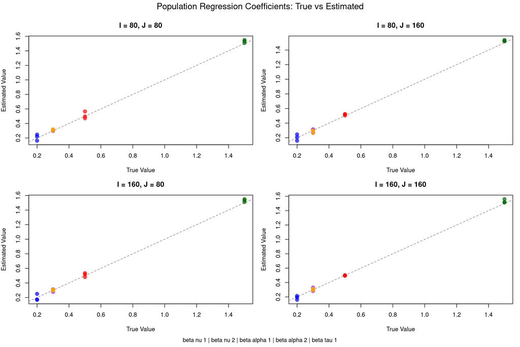

```r
# Define parameter groups and colors
beta_params <- c("beta_nu_1", "beta_nu_2", "beta_alpha_1", "beta_alpha_2", "beta_tau_1")
sigma_params <- c("sigma_nu", "sigma_alpha", "sigma_tau", "sigma_v")
beta_cols <- c("red", "blue", "darkgreen", "purple", "orange")
sigma_cols <- c("red", "blue", "darkgreen", "purple")

# Regression coefficients (beta parameters)
plot_recovery_population(pop_converged, beta_params, beta_cols,
                          "Population Regression Coefficients: True vs Estimated",
                          I_vals, J_vals)
```

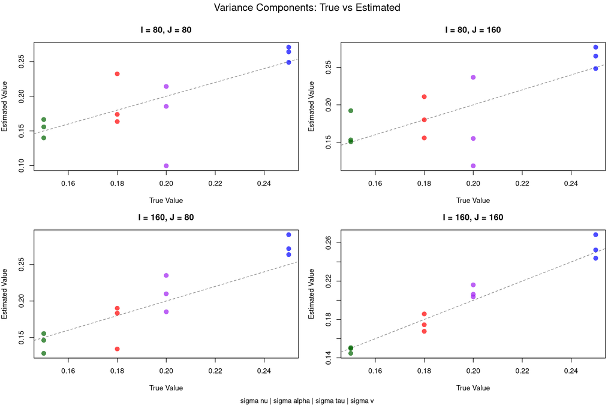

```r
# Variance components (sigma parameters)
plot_recovery_population(pop_converged, sigma_params, sigma_cols,
                          "Variance Components: True vs Estimated",
                          I_vals, J_vals)
```

Once again, there is a hidden r chunk in this .Rmd file that saves all the population-level plots to `JAGS/demos/simulation-study/design_matrix/figures`.

```
## Population plots saved to: /home/babymagikarp/Desktop/BayEZ/JAGS/demos/simulation-study/design_matrix/figures
```

## Summary Tables

```r
# Get unique design cells
design_cells <- unique(results_indiv_all[, c("I", "J")])

#####################################
# Compute correlations for each cell
#####################################

# Initialize the data frame to store the correlations
indiv_cors <- data.frame(I = integer(), J = integer(),
                        r_drift = numeric(), r_bound = numeric(),
                        r_nondt = numeric(), n_obs = integer())
# Fill the data frame with the correlations for each design cell
for (r in 1:nrow(design_cells)) {
    i_val <- design_cells$I[r]
    j_val <- design_cells$J[r]
    idx <- results_indiv_all$I == i_val & results_indiv_all$J == j_val
    sub_data <- results_indiv_all[idx, ]

    indiv_cors <- rbind(indiv_cors, data.frame(I = i_val, J = j_val,
                        r_drift = cor(sub_data$true_drift, sub_data$est_drift, use = "complete.obs"),
                        r_bound = cor(sub_data$true_bound, sub_data$est_bound, use = "complete.obs"),
                        r_nondt = cor(sub_data$true_nondt, sub_data$est_nondt, use = "complete.obs"),
                        n_obs = nrow(sub_data)))
}

# Show the correlations in a table
knitr::kable(indiv_cors, digits = 3,
             caption = "Individual-Level Correlations (True vs Estimated)")
```

Individual-Level Correlations (True vs Estimated)

| I | J | r_drift | r_bound | r_nondt | n_obs |
| --- | --- | --- | --- | --- | --- |
| 80 | 80 | 0.843 | 0.960 | 0.921 | 480 |
| 160 | 80 | 0.838 | 0.958 | 0.910 | 960 |
| 80 | 160 | 0.907 | 0.974 | 0.952 | 480 |
| 160 | 160 | 0.905 | 0.976 | 0.950 | 960 |

```r
#===============================================================================
# Bias and RMSE (Estimation at the population level)
#===============================================================================
# Get unique combinations
combos <- unique(pop_converged[, c("I", "J", "param")])

# Initialize the data frame to store the bias and RMSE
bias_summary <- data.frame(I = integer(), J = integer(),
                        param = character(),
                        true = numeric(),
                        mean_est = numeric(),
                        mean_bias = numeric(),
                        rmse = numeric())

# Fill the data frame with the bias and RMSE for each design cell
for (r in 1:nrow(combos)) {
    i_val <- combos$I[r]
    j_val <- combos$J[r]
    p_val <- combos$param[r]

    idx <- pop_converged$I == i_val & pop_converged$J == j_val & pop_converged$param == p_val
    sub_data <- pop_converged[idx, ]

    bias_summary <- rbind(bias_summary, data.frame(
        I = i_val, J = j_val, param = p_val,
        true = mean(sub_data$true_value),
        mean_est = mean(sub_data$estimate),
        mean_bias = mean(sub_data$estimate - sub_data$true_value),
        rmse = sqrt(mean((sub_data$estimate - sub_data$true_value)^2))
    ))
}

# Show the bias and RMSE in a table
knitr::kable(bias_summary, digits = 3,
             caption = "Population Parameter Recovery: Bias and RMSE by Design Cell")
```

Population Parameter Recovery: Bias and RMSE by Design Cell

| I | J | param | true | mean_est | mean_bias | rmse |
| --- | --- | --- | --- | --- | --- | --- |
| 80 | 80 | beta_nu_1 | 0.50 | 0.512 | 0.012 | 0.042 |
| 80 | 80 | beta_nu_2 | 0.20 | 0.210 | 0.010 | 0.036 |
| 80 | 80 | beta_alpha_1 | 1.50 | 1.530 | 0.030 | 0.035 |
| 80 | 80 | beta_alpha_2 | 0.30 | 0.303 | 0.003 | 0.006 |
| 80 | 80 | beta_tau_1 | 0.30 | 0.311 | 0.011 | 0.014 |
| 80 | 80 | sigma_nu | 0.18 | 0.190 | 0.010 | 0.032 |
| 80 | 80 | sigma_alpha | 0.25 | 0.261 | 0.011 | 0.015 |
| 80 | 80 | sigma_tau | 0.15 | 0.154 | 0.004 | 0.012 |
| 80 | 80 | sigma_v | 0.20 | 0.166 | -0.034 | 0.059 |
| 160 | 80 | beta_nu_1 | 0.50 | 0.511 | 0.011 | 0.025 |
| 160 | 80 | beta_nu_2 | 0.20 | 0.197 | -0.003 | 0.038 |
| 160 | 80 | beta_alpha_1 | 1.50 | 1.532 | 0.032 | 0.036 |
| 160 | 80 | beta_alpha_2 | 0.30 | 0.299 | -0.001 | 0.015 |
| 160 | 80 | beta_tau_1 | 0.30 | 0.303 | 0.003 | 0.006 |
| 160 | 80 | sigma_nu | 0.18 | 0.169 | -0.011 | 0.027 |
| 160 | 80 | sigma_alpha | 0.25 | 0.275 | 0.025 | 0.028 |
| 160 | 80 | sigma_tau | 0.15 | 0.143 | -0.007 | 0.013 |
| 160 | 80 | sigma_v | 0.20 | 0.210 | 0.010 | 0.023 |
| 80 | 160 | beta_nu_1 | 0.50 | 0.516 | 0.016 | 0.019 |
| 80 | 160 | beta_nu_2 | 0.20 | 0.204 | 0.004 | 0.035 |
| 80 | 160 | beta_alpha_1 | 1.50 | 1.527 | 0.027 | 0.028 |
| 80 | 160 | beta_alpha_2 | 0.30 | 0.299 | -0.001 | 0.020 |
| 80 | 160 | beta_tau_1 | 0.30 | 0.287 | -0.013 | 0.021 |
| 80 | 160 | sigma_nu | 0.18 | 0.182 | 0.002 | 0.023 |
| 80 | 160 | sigma_alpha | 0.25 | 0.264 | 0.014 | 0.018 |
| 80 | 160 | sigma_tau | 0.15 | 0.165 | 0.015 | 0.024 |
| 80 | 160 | sigma_v | 0.20 | 0.170 | -0.030 | 0.058 |
| 160 | 160 | beta_nu_1 | 0.50 | 0.498 | -0.002 | 0.004 |
| 160 | 160 | beta_nu_2 | 0.20 | 0.189 | -0.011 | 0.025 |
| 160 | 160 | beta_alpha_1 | 1.50 | 1.531 | 0.031 | 0.037 |
| 160 | 160 | beta_alpha_2 | 0.30 | 0.305 | 0.005 | 0.021 |
| 160 | 160 | beta_tau_1 | 0.30 | 0.303 | 0.003 | 0.009 |
| 160 | 160 | sigma_nu | 0.18 | 0.176 | -0.004 | 0.008 |
| 160 | 160 | sigma_alpha | 0.25 | 0.255 | 0.005 | 0.011 |
| 160 | 160 | sigma_tau | 0.15 | 0.148 | -0.002 | 0.003 |
| 160 | 160 | sigma_v | 0.20 | 0.209 | 0.009 | 0.010 |

# Simulation 2: Condition Effect on Non-Decision Time

As mentioned above, the JAGS model is flexible enough to accommodate different designs. Here, we present a second simulation study where we change the design to include a condition effect on non-decision time, but use the same JAGS model to recover the parameters.

| Parameter | Simulation 1 | Simulation 2 |
| --- | --- | --- |
| $P_\nu$ | 2 (intercept + condition) | 2 (unchanged) |
| $P_\alpha$ | 2 (intercept + covariate) | 2 (unchanged) |
| $P_\tau$ | 1 (intercept only) | **2 (intercept + condition)** |

To make this report more concise, I made sure the `run_one_simulation()` function could be used to accomodate both simulation studies.

Of course, however, what we truly care to demonstrate is the flexibility of the JAGS model to accommodate different designs. In this case, the only change needed is passing `P_tau = 2` and including a true condition effect `b1_tau` in the true parameter list. The JAGS model adapts automatically via `inprod()` and the `1:P_tau` loops.

### Update True Parameters

```r
# Same population values as Simulation 1, plus a condition effect on tau
true_pars_sim2 <- true_pars
true_pars_sim2$b1_tau <- 0.05   # Condition effect on non-decision time
```

### Run Simulation Study 2

Same $2 \times 2 \times 3 = 12$ design cells as Simulation 1.

```r
resultsFile_sim2 <- here("JAGS", "demos", "simulation-study", "design_matrix",
                         "simulation_results_tauCond.RData")

# Only run if the results file does not exist
if (file.exists(resultsFile_sim2)) {
    load(resultsFile_sim2)
} else {
    results_list_sim2 <- vector("list", nrow(sim_grid))

    for (r in 1:nrow(sim_grid)) {
        set.seed(r + 1000)  # Distinct seeds from Simulation 1

        cat("Sim 2 | Running", r, "of", nrow(sim_grid),
            "| I =", sim_grid$I[r], "| J =", sim_grid$J[r], "\n")

        # Key change: P_tau = 2
        results_list_sim2[[r]] <- run_one_simulation(
            I = sim_grid$I[r], J = sim_grid$J[r], K = K,
            true_pars = true_pars_sim2, modelFile = modelFile,
            P_nu = 2, P_alpha = 2, P_tau = 2)
    }

    save(results_list_sim2, sim_grid, true_pars_sim2, file = resultsFile_sim2)
}
```

### Aggregate Results (Simulation 2)

```r
#-------------------------------------------------------------------------------
# Population-level results
#-------------------------------------------------------------------------------
pop_results_sim2 <- do.call(rbind, lapply(seq_along(results_list_sim2), function(r) {
    res <- results_list_sim2[[r]]
    data.frame(sim = r, I = res$I, J = res$J,
               param = names(res$pop_est),
               true_value = res$pop_true,
               estimate = res$pop_est,
               converged = res$converged)
}))

#-------------------------------------------------------------------------------
# Individual-level results
#-------------------------------------------------------------------------------
results_indiv_sim2 <- do.call(rbind, lapply(seq_along(results_list_sim2), function(r) {
    res <- results_list_sim2[[r]]
    if (!res$converged) return(NULL)

    df <- res$results_indiv
    df$sim <- r
    df$I <- res$I
    df$J <- res$J
    df
}))

#-------------------------------------------------------------------------------
# Random slope results
#-------------------------------------------------------------------------------
results_v_sim2 <- do.call(rbind, lapply(seq_along(results_list_sim2), function(r) {
    res <- results_list_sim2[[r]]
    if (!res$converged) return(NULL)

    df <- res$results_v
    df$sim <- r
    df$I <- res$I
    df$J <- res$J
    df$true_v_total <- df$true_v + true_pars_sim2$b1_nu
    df$est_v_total <- df$est_v
    df
}))
```

```r
sum(!sapply(results_list_sim2, function(x) x$converged))
```

```
## [1] 0
```

We find that 0 simulations failed to converge.

## Individual-level Recovery plots

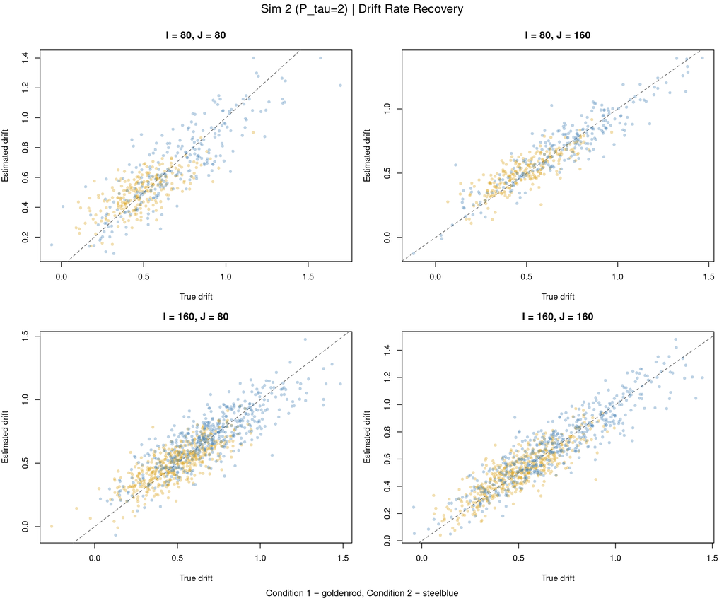

```r
plot_recovery_faceted(results_indiv_sim2, "true_drift", "est_drift",
                       "Sim 2 (P_tau=2) | Drift Rate Recovery",
                       "True drift", "Estimated drift",
                       I_vals, J_vals, by_condition = TRUE)
```

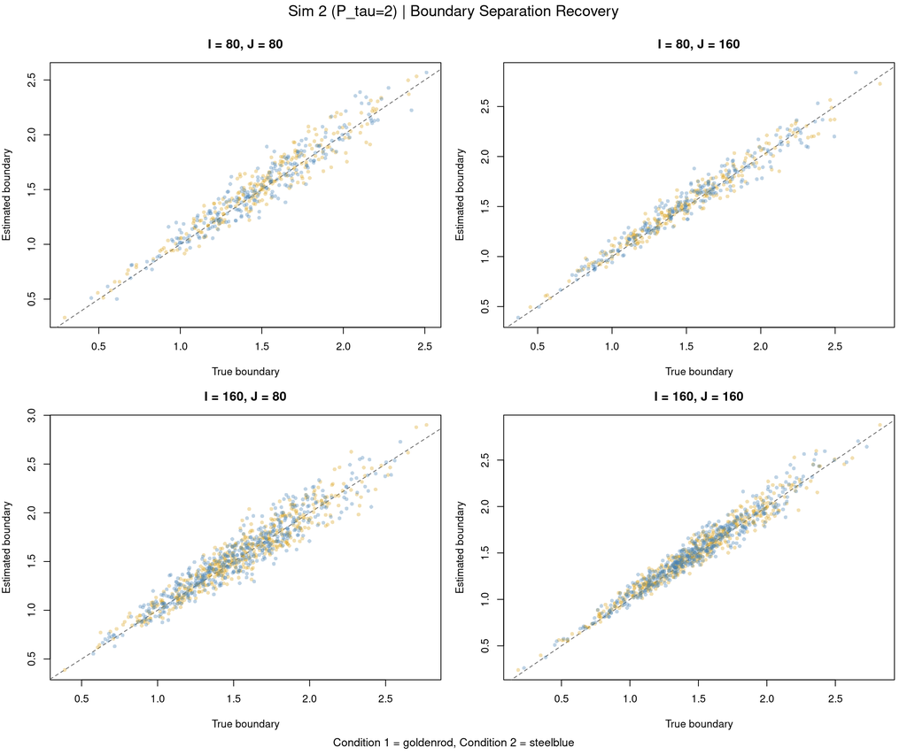

```r
plot_recovery_faceted(results_indiv_sim2, "true_bound", "est_bound",
                       "Sim 2 (P_tau=2) | Boundary Separation Recovery",
                       "True boundary", "Estimated boundary",
                       I_vals, J_vals, by_condition = TRUE)
```

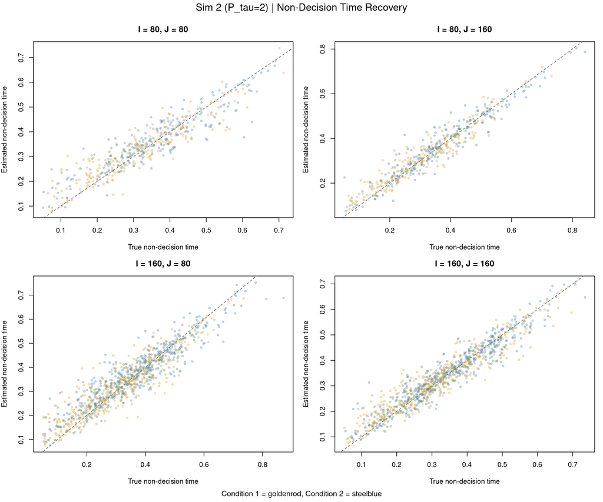

```r
plot_recovery_faceted(results_indiv_sim2, "true_nondt", "est_nondt",
                       "Sim 2 (P_tau=2) | Non-Decision Time Recovery",
                       "True non-decision time", "Estimated non-decision time",
                       I_vals, J_vals, by_condition = TRUE)
```

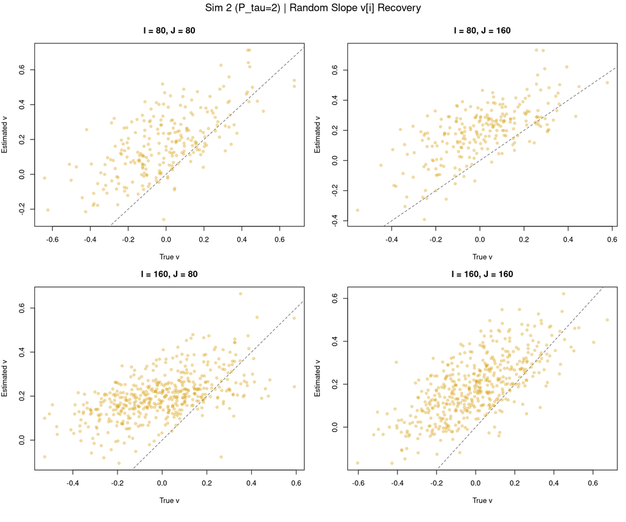

```
## Simulation 2 plots saved to: /home/babymagikarp/Desktop/BayEZ/JAGS/demos/simulation-study/design_matrix/figures_tauCond
```

```r
plot_recovery_faceted(results_v_sim2, "true_v", "est_v",
                       "Sim 2 (P_tau=2) | Random Slope v[i] Recovery",
                       "True v", "Estimated v",
                       I_vals, J_vals, by_condition = FALSE)
```

### Population-level Recovery plots

```r
pop_converged_sim2 <- pop_results_sim2[pop_results_sim2$converged, ]

beta_params_sim2 <- c("beta_nu_1", "beta_nu_2", "beta_alpha_1", "beta_alpha_2",
                      "beta_tau_1", "beta_tau_2")
sigma_params_sim2 <- c("sigma_nu", "sigma_alpha", "sigma_tau", "sigma_v")
beta_cols_sim2 <- c("red", "blue", "darkgreen", "purple", "orange", "brown")
sigma_cols_sim2 <- c("red", "blue", "darkgreen", "purple")
```

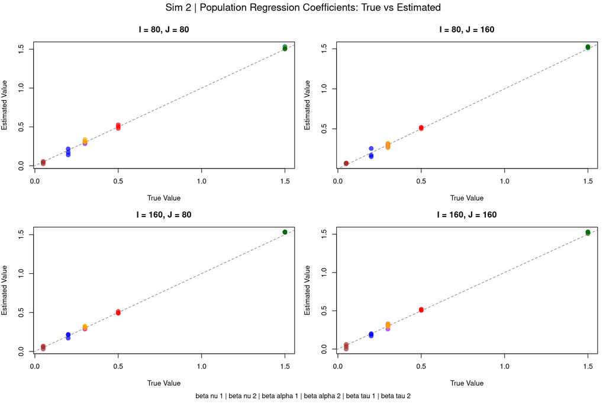

```r
plot_recovery_population(pop_converged_sim2, beta_params_sim2, beta_cols_sim2,
                          "Sim 2 | Population Regression Coefficients: True vs Estimated",
                          I_vals, J_vals)
```

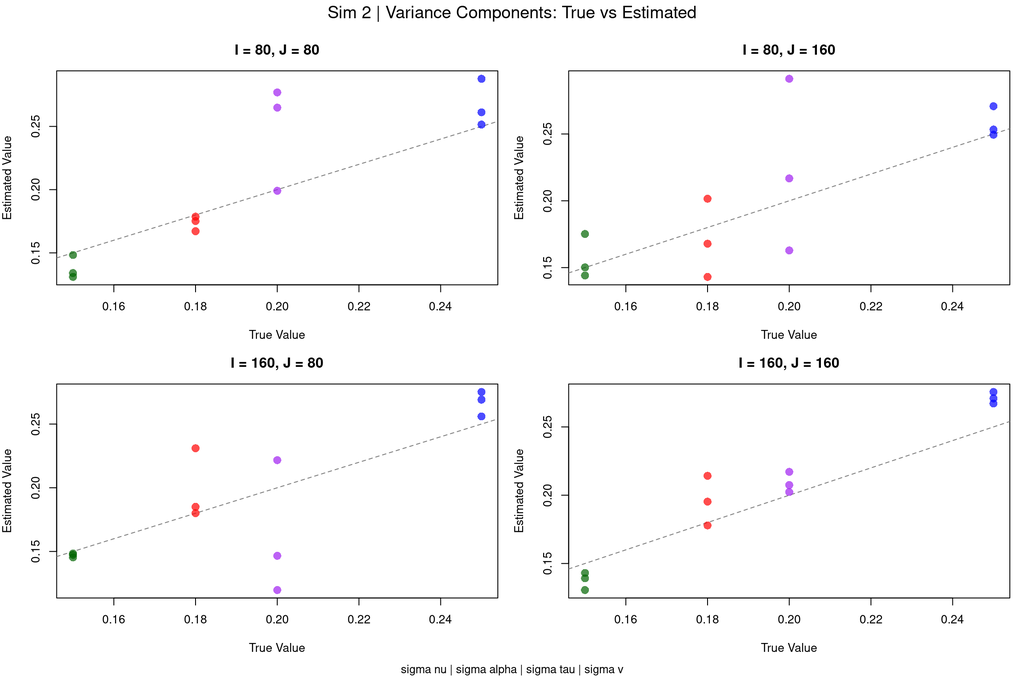

```
## Simulation 2 population plots saved to: /home/babymagikarp/Desktop/BayEZ/JAGS/demos/simulation-study/design_matrix/figures_tauCond
```

```r
plot_recovery_population(pop_converged_sim2, sigma_params_sim2, sigma_cols_sim2,
                          "Sim 2 | Variance Components: True vs Estimated",
                          I_vals, J_vals)
```

## Summary Tables (Simulation 2)

```r
#===============================================================================
# Individual-level correlations by design cell
#===============================================================================
design_cells_sim2 <- unique(results_indiv_sim2[, c("I", "J")])

indiv_cors_sim2 <- data.frame(I = integer(), J = integer(),
    r_drift = numeric(), r_bound = numeric(), r_nondt = numeric(),
    n_obs = integer())

for (r in 1:nrow(design_cells_sim2)) {
    i_val <- design_cells_sim2$I[r]
    j_val <- design_cells_sim2$J[r]
    idx <- results_indiv_sim2$I == i_val & results_indiv_sim2$J == j_val
    sub_data <- results_indiv_sim2[idx, ]

    indiv_cors_sim2 <- rbind(indiv_cors_sim2, data.frame(
        I = i_val, J = j_val,
        r_drift = cor(sub_data$true_drift, sub_data$est_drift, use = "complete.obs"),
        r_bound = cor(sub_data$true_bound, sub_data$est_bound, use = "complete.obs"),
        r_nondt = cor(sub_data$true_nondt, sub_data$est_nondt, use = "complete.obs"),
        n_obs = nrow(sub_data)
    ))
}

knitr::kable(indiv_cors_sim2, digits = 3,
             caption = "Simulation 2: Individual-Level Correlations (True vs Estimated)")
```

Simulation 2: Individual-Level Correlations (True vs Estimated)

| I | J | r_drift | r_bound | r_nondt | n_obs |
| --- | --- | --- | --- | --- | --- |
| 80 | 80 | 0.846 | 0.962 | 0.918 | 480 |
| 160 | 80 | 0.853 | 0.956 | 0.920 | 960 |
| 80 | 160 | 0.917 | 0.979 | 0.959 | 480 |
| 160 | 160 | 0.911 | 0.978 | 0.951 | 960 |

```r
#===============================================================================
# Population-level bias and RMSE
#===============================================================================
combos_sim2 <- unique(pop_converged_sim2[, c("I", "J", "param")])

bias_summary_sim2 <- data.frame(
    I = integer(), J = integer(), param = character(),
    true = numeric(), mean_est = numeric(),
    mean_bias = numeric(), rmse = numeric()
)

for (r in 1:nrow(combos_sim2)) {
    i_val <- combos_sim2$I[r]
    j_val <- combos_sim2$J[r]
    p_val <- combos_sim2$param[r]

    idx <- pop_converged_sim2$I == i_val & pop_converged_sim2$J == j_val &
           pop_converged_sim2$param == p_val
    sub_data <- pop_converged_sim2[idx, ]

    bias_summary_sim2 <- rbind(bias_summary_sim2, data.frame(
        I = i_val, J = j_val, param = p_val,
        true = mean(sub_data$true_value),
        mean_est = mean(sub_data$estimate),
        mean_bias = mean(sub_data$estimate - sub_data$true_value),
        rmse = sqrt(mean((sub_data$estimate - sub_data$true_value)^2))
    ))
}

knitr::kable(bias_summary_sim2, digits = 3,
             caption = "Simulation 2: Population Parameter Recovery (Bias and RMSE)")
```

Simulation 2: Population Parameter Recovery (Bias and RMSE)

| I | J | param | true | mean_est | mean_bias | rmse |
| --- | --- | --- | --- | --- | --- | --- |
| 80 | 80 | beta_nu_1 | 0.50 | 0.504 | 0.004 | 0.019 |
| 80 | 80 | beta_nu_2 | 0.20 | 0.176 | -0.024 | 0.040 |
| 80 | 80 | beta_alpha_1 | 1.50 | 1.515 | 0.015 | 0.020 |
| 80 | 80 | beta_alpha_2 | 0.30 | 0.293 | -0.007 | 0.010 |
| 80 | 80 | beta_tau_1 | 0.30 | 0.318 | 0.018 | 0.023 |
| 80 | 80 | beta_tau_2 | 0.05 | 0.041 | -0.009 | 0.015 |
| 80 | 80 | sigma_nu | 0.18 | 0.174 | -0.006 | 0.008 |
| 80 | 80 | sigma_alpha | 0.25 | 0.267 | 0.017 | 0.023 |
| 80 | 80 | sigma_tau | 0.15 | 0.138 | -0.012 | 0.014 |
| 80 | 80 | sigma_v | 0.20 | 0.247 | 0.047 | 0.058 |
| 160 | 80 | beta_nu_1 | 0.50 | 0.500 | 0.000 | 0.010 |
| 160 | 80 | beta_nu_2 | 0.20 | 0.201 | 0.001 | 0.021 |
| 160 | 80 | beta_alpha_1 | 1.50 | 1.534 | 0.034 | 0.034 |
| 160 | 80 | beta_alpha_2 | 0.30 | 0.295 | -0.005 | 0.010 |
| 160 | 80 | beta_tau_1 | 0.30 | 0.313 | 0.013 | 0.017 |
| 160 | 80 | beta_tau_2 | 0.05 | 0.053 | 0.003 | 0.016 |
| 160 | 80 | sigma_nu | 0.18 | 0.199 | 0.019 | 0.030 |
| 160 | 80 | sigma_alpha | 0.25 | 0.267 | 0.017 | 0.019 |
| 160 | 80 | sigma_tau | 0.15 | 0.147 | -0.003 | 0.003 |
| 160 | 80 | sigma_v | 0.20 | 0.163 | -0.037 | 0.057 |
| 80 | 160 | beta_nu_1 | 0.50 | 0.511 | 0.011 | 0.013 |
| 80 | 160 | beta_nu_2 | 0.20 | 0.192 | -0.008 | 0.046 |
| 80 | 160 | beta_alpha_1 | 1.50 | 1.522 | 0.022 | 0.023 |
| 80 | 160 | beta_alpha_2 | 0.30 | 0.294 | -0.006 | 0.015 |
| 80 | 160 | beta_tau_1 | 0.30 | 0.293 | -0.007 | 0.024 |
| 80 | 160 | beta_tau_2 | 0.05 | 0.068 | 0.018 | 0.019 |
| 80 | 160 | sigma_nu | 0.18 | 0.171 | -0.009 | 0.026 |
| 80 | 160 | sigma_alpha | 0.25 | 0.258 | 0.008 | 0.012 |
| 80 | 160 | sigma_tau | 0.15 | 0.156 | 0.006 | 0.015 |
| 80 | 160 | sigma_v | 0.20 | 0.224 | 0.024 | 0.058 |
| 160 | 160 | beta_nu_1 | 0.50 | 0.512 | 0.012 | 0.013 |
| 160 | 160 | beta_nu_2 | 0.20 | 0.187 | -0.013 | 0.018 |
| 160 | 160 | beta_alpha_1 | 1.50 | 1.524 | 0.024 | 0.026 |
| 160 | 160 | beta_alpha_2 | 0.30 | 0.295 | -0.005 | 0.026 |
| 160 | 160 | beta_tau_1 | 0.30 | 0.312 | 0.012 | 0.020 |
| 160 | 160 | beta_tau_2 | 0.05 | 0.031 | -0.019 | 0.031 |
| 160 | 160 | sigma_nu | 0.18 | 0.196 | 0.016 | 0.022 |
| 160 | 160 | sigma_alpha | 0.25 | 0.271 | 0.021 | 0.021 |
| 160 | 160 | sigma_tau | 0.15 | 0.138 | -0.012 | 0.013 |
| 160 | 160 | sigma_v | 0.20 | 0.209 | 0.009 | 0.011 |

# Conclusion

We ran two separate simulation studies with different design matrices, and used the **same JAGS model file** to retrieve posterior estimates.

- Simulation 1 included only one predictor of the nondt `P_tau = 1` (i.e. only intercept).
- Simulation 2 included two predictors of the nondt `P_tau = 2` (i.e. intercept + condition dummy)
- Both simulation studies differ in the design array $X_\tau$

Across both simulations, using the same JAGS model resulted in appropriate parameter recovery results.